# This Notebook uses RSEM coutns

```r
library(repr)
options(repr.plot.width=7, repr.plot.height=7)
```

if (!requireNamespace("BiocManager", quietly = TRUE)) install.packages("BiocManager") BiocManager::install("tmm")

```r
library(tidyverse)
library(WriteXLS)
```

```r
library(DESeq2)
library(apeglm)
library(EnhancedVolcano)
library(pheatmap)
```

```r
setwd('/gpfs/commons/groups/sanjana_lab/cdai/TFscreen/')
```

```r
list.files('.', 'rsem')
```

'rsem_counts_B1B2_combined.csv'

```r
cnts <- read.csv(file = 'rsem_counts_B1B2_combined.csv')
```

```r
cnts %>% head
```

A data.frame: 6 × 45

|  | gene_name <fct> | S01_B1 <int> | S01_B2 <int> | S02_B1 <int> | S02_B2 <int> | S03_B1 <int> | S03_B2 <int> | S04_B1 <int> | S04_B2 <int> | S05_B1 <int> | ⋯ | S18_B1 <int> | S18_B2 <int> | S19_B1 <int> | S19_B2 <int> | S20_B1 <int> | S20_B2 <int> | S21_B1 <int> | S21_B2 <int> | S22_B1 <int> | S22_B2 <int> |
| --- | --- | --- | --- | --- | --- | --- | --- | --- | --- | --- | --- | --- | --- | --- | --- | --- | --- | --- | --- | --- | --- |
| ENSG00000000003.14 | TSPAN6 | 817 | 966 | 789 | 1226 | 757 | 723 | 991 | 1400 | 1194 | ⋯ | 1262 | 2215 | 1604 | 2076 | 1064 | 2301 | 175 | 457 | 294 | 584 |
| ENSG00000000005.6 | TNMD | 19 | 0 | 0 | 11 | 11 | 14 | 1 | 11 | 0 | ⋯ | 0 | 2 | 0 | 0 | 0 | 1 | 0 | 0 | 0 | 0 |
| ENSG00000000419.12 | DPM1 | 762 | 731 | 746 | 908 | 809 | 644 | 516 | 1264 | 340 | ⋯ | 853 | 901 | 797 | 791 | 345 | 1147 | 378 | 400 | 255 | 567 |
| ENSG00000000457.14 | SCYL3 | 20 | 67 | 49 | 70 | 28 | 27 | 56 | 14 | 65 | ⋯ | 0 | 58 | 129 | 46 | 82 | 80 | 46 | 31 | 111 | 124 |
| ENSG00000000460.17 | C1orf112 | 114 | 211 | 160 | 266 | 153 | 145 | 101 | 253 | 148 | ⋯ | 146 | 165 | 114 | 187 | 118 | 126 | 54 | 0 | 0 | 1 |
| ENSG00000000938.13 | FGR | 0 | 0 | 0 | 0 | 0 | 0 | 0 | 0 | 0 | ⋯ | 0 | 0 | 0 | 0 | 0 | 2 | 0 | 0 | 0 | 0 |

```r
cnts[,3:46] <- apply(cnts[,3:46],2, as.integer) # convert rsem floating data to integer
```

```r
cnts <- cnts %>% column_to_rownames('gene_id')
```

```r
str(cnts)
head(cnts)
```

```
'data.frame':	60662 obs. of  45 variables:
 $ gene_name: Factor w/ 59087 levels "A1BG","A1BG-AS1",..: 56272 55504 27106 51431 23421 28996 24837 29441 29754 40806 ...
 $ S01_B1   : int  817 19 762 20 114 0 0 229 146 168 ...
 $ S01_B2   : int  966 0 731 67 211 0 1 396 60 237 ...
 $ S02_B1   : int  789 0 746 49 160 0 0 190 177 145 ...
 $ S02_B2   : int  1226 11 908 70 266 0 0 409 330 248 ...
 $ S03_B1   : int  757 11 809 28 153 0 0 277 202 72 ...
 $ S03_B2   : int  723 14 644 27 145 0 0 140 205 206 ...
 $ S04_B1   : int  991 1 516 56 101 0 0 229 39 148 ...
 $ S04_B2   : int  1400 11 1264 14 253 0 1 523 401 194 ...
 $ S05_B1   : int  1194 0 340 65 148 0 0 313 131 292 ...
 $ S05_B2   : int  1732 14 1031 37 271 0 0 557 366 247 ...
 $ S06_B1   : int  1093 0 597 40 94 0 0 546 78 202 ...
 $ S06_B2   : int  2456 19 1772 41 361 0 4 691 579 471 ...
 $ S07_B1   : int  739 0 390 138 0 0 0 80 54 166 ...
```

[output cut: 31 more lines]

A data.frame: 6 × 45

|  | gene_name <fct> | S01_B1 <int> | S01_B2 <int> | S02_B1 <int> | S02_B2 <int> | S03_B1 <int> | S03_B2 <int> | S04_B1 <int> | S04_B2 <int> | S05_B1 <int> | ⋯ | S18_B1 <int> | S18_B2 <int> | S19_B1 <int> | S19_B2 <int> | S20_B1 <int> | S20_B2 <int> | S21_B1 <int> | S21_B2 <int> | S22_B1 <int> | S22_B2 <int> |
| --- | --- | --- | --- | --- | --- | --- | --- | --- | --- | --- | --- | --- | --- | --- | --- | --- | --- | --- | --- | --- | --- |
| ENSG00000000003.14 | TSPAN6 | 817 | 966 | 789 | 1226 | 757 | 723 | 991 | 1400 | 1194 | ⋯ | 1262 | 2215 | 1604 | 2076 | 1064 | 2301 | 175 | 457 | 294 | 584 |
| ENSG00000000005.6 | TNMD | 19 | 0 | 0 | 11 | 11 | 14 | 1 | 11 | 0 | ⋯ | 0 | 2 | 0 | 0 | 0 | 1 | 0 | 0 | 0 | 0 |
| ENSG00000000419.12 | DPM1 | 762 | 731 | 746 | 908 | 809 | 644 | 516 | 1264 | 340 | ⋯ | 853 | 901 | 797 | 791 | 345 | 1147 | 378 | 400 | 255 | 567 |
| ENSG00000000457.14 | SCYL3 | 20 | 67 | 49 | 70 | 28 | 27 | 56 | 14 | 65 | ⋯ | 0 | 58 | 129 | 46 | 82 | 80 | 46 | 31 | 111 | 124 |
| ENSG00000000460.17 | C1orf112 | 114 | 211 | 160 | 266 | 153 | 145 | 101 | 253 | 148 | ⋯ | 146 | 165 | 114 | 187 | 118 | 126 | 54 | 0 | 0 | 1 |
| ENSG00000000938.13 | FGR | 0 | 0 | 0 | 0 | 0 | 0 | 0 | 0 | 0 | ⋯ | 0 | 0 | 0 | 0 | 0 | 2 | 0 | 0 | 0 | 0 |

# Preliminary

```r
mean_cnts <- apply(cnts[,2:45], 1, mean)
var_cnts <- apply(cnts[,2:45], 1, var)
df <- data.frame(mean_cnts, var_cnts)
```

```r
?scale_y_log10
```

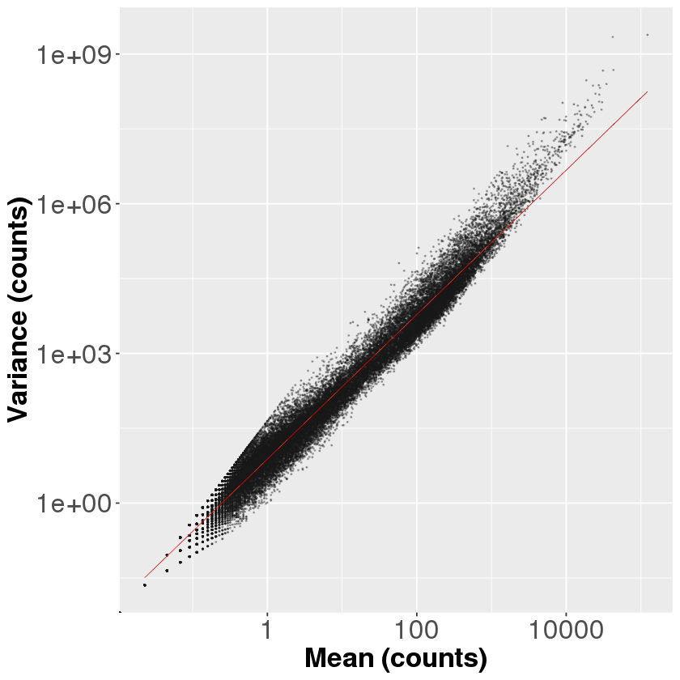

```r
ggplot(df) + geom_point(aes(x=mean_cnts, y=var_cnts), size=.2, alpha=0.3, color="grey10") +
             geom_smooth(aes(x=mean_cnts, y=var_cnts),method = 'glm', size=.2, color='red', alpha=1) +
             labs(y="Variance (counts)", x="Mean (counts)") +
             scale_y_log10() + scale_x_log10() +
             theme(axis.text.x = element_text(size = 20), axis.title.x = element_text(size=20, face='bold'),
                   axis.text.y = element_text(size = 20), axis.title.y = element_text(size=20, face='bold'))
```

```r
cnts %>% head(2)
```

A data.frame: 2 × 45

|  | gene_name <fct> | S01_B1 <int> | S01_B2 <int> | S02_B1 <int> | S02_B2 <int> | S03_B1 <int> | S03_B2 <int> | S04_B1 <int> | S04_B2 <int> | S05_B1 <int> | ⋯ | S18_B1 <int> | S18_B2 <int> | S19_B1 <int> | S19_B2 <int> | S20_B1 <int> | S20_B2 <int> | S21_B1 <int> | S21_B2 <int> | S22_B1 <int> | S22_B2 <int> |
| --- | --- | --- | --- | --- | --- | --- | --- | --- | --- | --- | --- | --- | --- | --- | --- | --- | --- | --- | --- | --- | --- |
| ENSG00000000003.14 | TSPAN6 | 817 | 966 | 789 | 1226 | 757 | 723 | 991 | 1400 | 1194 | ⋯ | 1262 | 2215 | 1604 | 2076 | 1064 | 2301 | 175 | 457 | 294 | 584 |
| ENSG00000000005.6 | TNMD | 19 | 0 | 0 | 11 | 11 | 14 | 1 | 11 | 0 | ⋯ | 0 | 2 | 0 | 0 | 0 | 1 | 0 | 0 | 0 | 0 |

Check correlation between replicates

```r
library(repr)
options(repr.plot.width=14, repr.plot.height=10)
```

WT.ES 1, 2 108.ES 3, 4 112.ES 5, 6 WT.Day4 7,8 108.Day4 9, 10 112.Day4 11, 12

```r
cnts_tpm <- read.csv(file = 'data/H2HY7BGXC/rsem_results/rsem_TPM.csv')
```

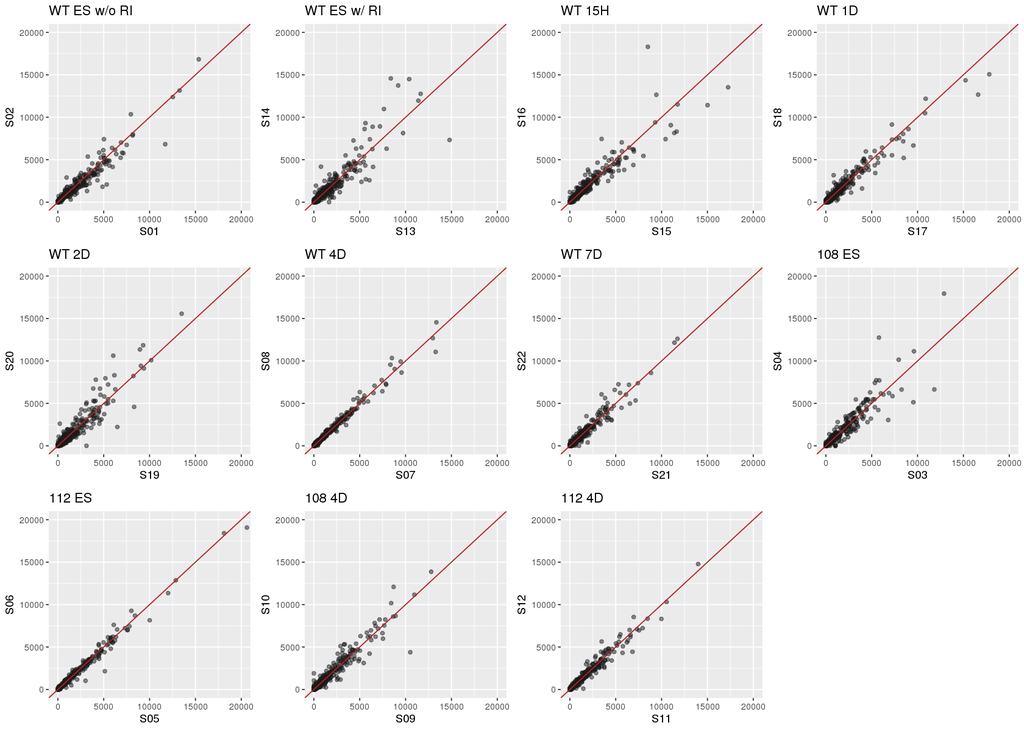

```r
gg <- ggplot(cnts_tpm)
p1 <- gg + geom_point(aes(x=S01, y=S02), color='grey10', alpha=0.5) + geom_abline(slope = 1, color='firebrick') + coord_cartesian(xlim = c(0,2e04), ylim = c(0,2e04)) + labs(title = "WT ES w/o RI")
p2 <- gg + geom_point(aes(x=S13, y=S14), color='grey10', alpha=0.5) + geom_abline(slope = 1, color='firebrick') + coord_cartesian(xlim = c(0,2e04), ylim = c(0,2e04)) + labs(title = "WT ES w/ RI")
p3 <- gg + geom_point(aes(x=S15, y=S16), color='grey10', alpha=0.5) + geom_abline(slope = 1, color='firebrick') + coord_cartesian(xlim = c(0,2e04), ylim = c(0,2e04)) + labs(title = "WT 15H")
p4 <- gg + geom_point(aes(x=S17, y=S18), color='grey10', alpha=0.5) + geom_abline(slope = 1, color='firebrick') + coord_cartesian(xlim = c(0,2e04), ylim = c(0,2e04)) + labs(title = "WT 1D")
p5 <- gg + geom_point(aes(x=S19, y=S20), color='grey10', alpha=0.5) + geom_abline(slope = 1, color='firebrick') + coord_cartesian(xlim = c(0,2e04), ylim = c(0,2e04)) + labs(title = "WT 2D")
p6 <- gg + geom_point(aes(x=S07, y=S08), color='grey10', alpha=0.5) + geom_abline(slope = 1, color='firebrick') + coord_cartesian(xlim = c(0,2e04), ylim = c(0,2e04)) + labs(title = "WT 4D")
p7 <- gg + geom_point(aes(x=S21, y=S22), color='grey10', alpha=0.5) + geom_abline(slope = 1, color='firebrick') + coord_cartesian(xlim = c(0,2e04), ylim = c(0,2e04)) + labs(title = "WT 7D")
p8 <- gg + geom_point(aes(x=S03, y=S04), color='grey10', alpha=0.5) + geom_abline(slope = 1, color='firebrick') + coord_cartesian(xlim = c(0,2e04), ylim = c(0,2e04)) + labs(title = "108 ES")
p9 <- gg + geom_point(aes(x=S05, y=S06), color='grey10', alpha=0.5) + geom_abline(slope = 1, color='firebrick') + coord_cartesian(xlim = c(0,2e04), ylim = c(0,2e04)) + labs(title = "112 ES")
p10 <- gg + geom_point(aes(x=S09, y=S10), color='grey10', alpha=0.5) + geom_abline(slope = 1, color='firebrick') + coord_cartesian(xlim = c(0,2e04), ylim = c(0,2e04)) + labs(title = "108 4D")
p11 <- gg + geom_point(aes(x=S11, y=S12), color='grey10', alpha=0.5) + geom_abline(slope = 1, color='firebrick') + coord_cartesian(xlim = c(0,2e04), ylim = c(0,2e04)) + labs(title = "112 4D")


gridExtra::grid.arrange(p1, p2, p3, p4, p5, p6, p7,p8,p9,p10,p11, ncol=4)
```

# ACT III

**WT with devlopment:**

| Condition | Sample |
| --- | --- |
| ES w/o RI | 1, 2 |
| ES w/ RI | 13, 14 |
| +DOX 15h | 15, 16 |
| +DOX Day1 | 17, 18 |
| +DOX Day2 | 19, 20 |
| +DOX Day4 | 7, 8 |
| +DOX Day7 | 21, 22 |

contrasts: ES, 15H, 1D, 2D, 4D, 7D

```r
all.sample.annotation <- read.csv('RNASeqSampleNames.csv', stringsAsFactors=F)
```

```r
all.sample.annotation %>% head
```

A data.frame: 6 × 3

| sample <chr> | condition <chr> | group <chr> |
| --- | --- | --- |
| S01_B1 | WT.ES | ES |
| S01_B2 | WT.ES | ES |
| S02_B1 | WT.ES | ES |
| S02_B2 | WT.ES | ES |
| S03_B1 | K108.ES | KO.ES |
| S03_B2 | K108.ES | KO.ES |

```r
# sample names for WT at different time points: 15H , 1D, 2D, 4D, 7D
cols3 <- all.sample.annotation %>% filter(str_detect(sample, 'S01|02|13|14|15|16|17|18|19|20|07|08|21|22.+')) %>% pull(sample)
```

```r
cols3 %>% t
```

A matrix: 1 × 28 of type chr

| S01_B1 | S01_B2 | S02_B1 | S02_B2 | S07_B1 | S07_B2 | S08_B1 | S08_B2 | S13_B1 | S13_B2 | ⋯ | S18_B1 | S18_B2 | S19_B1 | S19_B2 | S20_B1 | S20_B2 | S21_B1 | S21_B2 | S22_B1 | S22_B2 |
| --- | --- | --- | --- | --- | --- | --- | --- | --- | --- | --- | --- | --- | --- | --- | --- | --- | --- | --- | --- | --- |

```r
cnts3<- cnts[,cols3]
```

```r
gtf_lookup = read.csv('/gpfs/commons/groups/sanjana_lab/cdai/ref_genome/gencode.v31.primary_assembly.annotation.gene_idTOgene_name.txt') #gencode gene_id to gene_name lookup
```

```r
gene_ids3 = rownames_to_column(cnts3,'gene_id')[,1:2]
gtf_lookup$gene_id <- as.character(gtf_lookup$gene_id)
gene_names3 = left_join(gene_ids3, gtf_lookup, 'gene_id') %>% pull(gene_name) %>% as.character
```

```r
gene_names3 %>% str
```

```
 chr [1:60662] "TSPAN6" "TNMD" "DPM1" "SCYL3" "C1orf112" "FGR" "CFH" ...
```

```r
all.sample.annotation %>% str
```

```
'data.frame':	44 obs. of  3 variables:
 $ sample   : chr  "S01_B1" "S01_B2" "S02_B1" "S02_B2" ...
 $ condition: chr  "WT.ES" "WT.ES" "WT.ES" "WT.ES" ...
 $ group    : chr  "ES" "ES" "ES" "ES" ...
```

```r
# label column names
coldata3 <- all.sample.annotation %>% column_to_rownames('sample')
coldata3 <- coldata3[cols3,]
```

```r
coldata3 %>% t
cnts3 %>% colnames %>% t
```

A matrix: 2 × 28 of type chr

|  | S01_B1 | S01_B2 | S02_B1 | S02_B2 | S07_B1 | S07_B2 | S08_B1 | S08_B2 | S13_B1 | S13_B2 | ⋯ | S18_B1 | S18_B2 | S19_B1 | S19_B2 | S20_B1 | S20_B2 | S21_B1 | S21_B2 | S22_B1 | S22_B2 |
| --- | --- | --- | --- | --- | --- | --- | --- | --- | --- | --- | --- | --- | --- | --- | --- | --- | --- | --- | --- | --- | --- |
| condition | WT.ES | WT.ES | WT.ES | WT.ES | WT.D4 | WT.D4 | WT.D4 | WT.D4 | WT.ES | WT.ES | ⋯ | WT.D1 | WT.D1 | WT.D2 | WT.D2 | WT.D2 | WT.D2 | WT.D7 | WT.D7 | WT.D7 | WT.D7 |
| group | ES | ES | ES | ES | D4 | D4 | D4 | D4 | ES | ES | ⋯ | D1 | D1 | D2 | D2 | D2 | D2 | D7 | D7 | D7 | D7 |

A matrix: 1 × 28 of type chr

| S01_B1 | S01_B2 | S02_B1 | S02_B2 | S07_B1 | S07_B2 | S08_B1 | S08_B2 | S13_B1 | S13_B2 | ⋯ | S18_B1 | S18_B2 | S19_B1 | S19_B2 | S20_B1 | S20_B2 | S21_B1 | S21_B2 | S22_B1 | S22_B2 |
| --- | --- | --- | --- | --- | --- | --- | --- | --- | --- | --- | --- | --- | --- | --- | --- | --- | --- | --- | --- | --- |

```r
dds3 <- DESeqDataSetFromMatrix(countData = cnts3, colData = coldata3, design = ~ group)
```

```r
all(rownames(dds3) == gene_ids3$gene_id) # make sure all gene_ids are the same as the gene ids in dds
```

TRUE

```r
mcols(dds3) <- cbind(mcols(dds3), 'gene_name' = gene_names3) # adding gene_names to counts dds
```

```r
keep3 <- rowSums(counts(dds3)) >= 10 # pre-analysis filter to remove very low read count genes
dds3 <- dds3[keep3,]
```

```r
dim(dds3)
```

1. 29757

2. 28

# specify factor level, not needed since Deseq2 will do it automatically dds3$condition <- factor(dds3$condition, levels = unique(as.vector(coldata3$condition))) dds3$group <- factor(dds3$group, levels = unique(as.vector(coldata3$group)))

```r
counts(dds3) %>% head()
```

A matrix: 6 × 28 of type int

|  | S01_B1 | S01_B2 | S02_B1 | S02_B2 | S07_B1 | S07_B2 | S08_B1 | S08_B2 | S13_B1 | S13_B2 | ⋯ | S18_B1 | S18_B2 | S19_B1 | S19_B2 | S20_B1 | S20_B2 | S21_B1 | S21_B2 | S22_B1 | S22_B2 |
| --- | --- | --- | --- | --- | --- | --- | --- | --- | --- | --- | --- | --- | --- | --- | --- | --- | --- | --- | --- | --- | --- |
| ENSG00000000003.14 | 817 | 966 | 789 | 1226 | 739 | 359 | 998 | 1247 | 1228 | 1891 | ⋯ | 1262 | 2215 | 1604 | 2076 | 1064 | 2301 | 175 | 457 | 294 | 584 |
| ENSG00000000005.6 | 19 | 0 | 0 | 11 | 0 | 0 | 0 | 1 | 25 | 36 | ⋯ | 0 | 2 | 0 | 0 | 0 | 1 | 0 | 0 | 0 | 0 |
| ENSG00000000419.12 | 762 | 731 | 746 | 908 | 390 | 235 | 513 | 774 | 770 | 932 | ⋯ | 853 | 901 | 797 | 791 | 345 | 1147 | 378 | 400 | 255 | 567 |
| ENSG00000000457.14 | 20 | 67 | 49 | 70 | 138 | 29 | 168 | 43 | 90 | 96 | ⋯ | 0 | 58 | 129 | 46 | 82 | 80 | 46 | 31 | 111 | 124 |
| ENSG00000000460.17 | 114 | 211 | 160 | 266 | 0 | 14 | 70 | 38 | 136 | 368 | ⋯ | 146 | 165 | 114 | 187 | 118 | 126 | 54 | 0 | 0 | 1 |
| ENSG00000000938.13 | 0 | 0 | 0 | 0 | 0 | 0 | 0 | 0 | 0 | 0 | ⋯ | 0 | 0 | 0 | 0 | 0 | 2 | 0 | 0 | 0 | 0 |

```r
dds3 <- DESeq(dds3) # build model
```

```
-- replacing outliers and refitting for 584 genes
-- DESeq argument 'minReplicatesForReplace' = 7
-- original counts are preserved in counts(dds)
```

```r
resultsNames(dds3) # model coefficients
```

1. 'Intercept'

2. 'group_D2_vs_D1'

3. 'group_D4_vs_D1'

4. 'group_D7_vs_D1'

5. 'group_ES_vs_D1'

6. 'group_H15_vs_D1'

### Volcano plots

#### 15H vs. WT

```r
res3a <- results(dds3, contrast = c('group','H15','ES')) # modelling ES vs. +DOX

# add gene_name to result
if (all(rownames(res3a) == rownames(dds3))) {
    res3a.df <- cbind(res3a, 'gene_name' = mcols(dds3)$gene_name) %>% as.data.frame %>% rownames_to_column('gene_id') %>% filter(!is.na(padj))
}  else {
    print("Rownames don't match!")
}
```

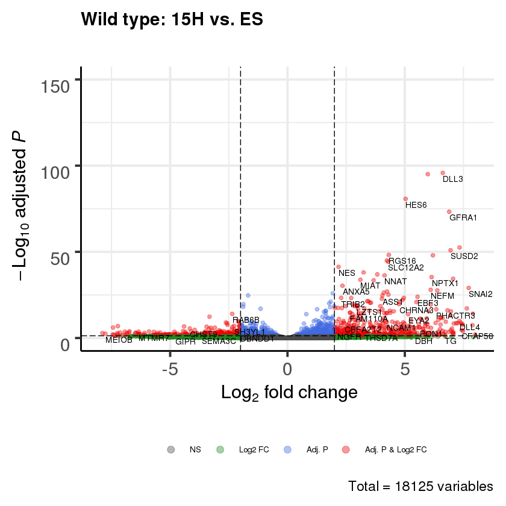

```r
EnhancedVolcano(res3a.df, lab = res3a.df$gene_name, x='log2FoldChange',y='padj', xlim=c(-8,8), ylim=c(0,150),
                xlab = bquote(~Log[2]~ 'fold change'), ylab= bquote(~-Log[10]~adjusted~italic(P)),
                legend=c('NS','Log2 FC','Adj. P', 'Adj. P & Log2 FC'),legendPosition='bottom', legendLabSize = 8,
                legendIconSize = 3.0, title = "Wild type: 15H vs. ES", subtitle="", pCutoff = 0.05, FCcutoff = 2,
                transcriptPointSize = 1.5, transcriptLabSize = 3.0, colAlpha = .4)
# selectLab = c('FHL3', 'STRAG') to only label key transcripts
```

#### 1D vs. WT

```r
res3b <- results(dds3, contrast = c('group','D1','ES'))

# add gene_name to result
if (all(rownames(res3b) == rownames(dds3))) {
    res3b.df <- cbind(res3b, 'gene_name' = mcols(dds3)$gene_name) %>% as.data.frame %>% rownames_to_column('gene_id') %>% filter(!is.na(padj))
}  else {
    print("Rownames don't match!")
}
```

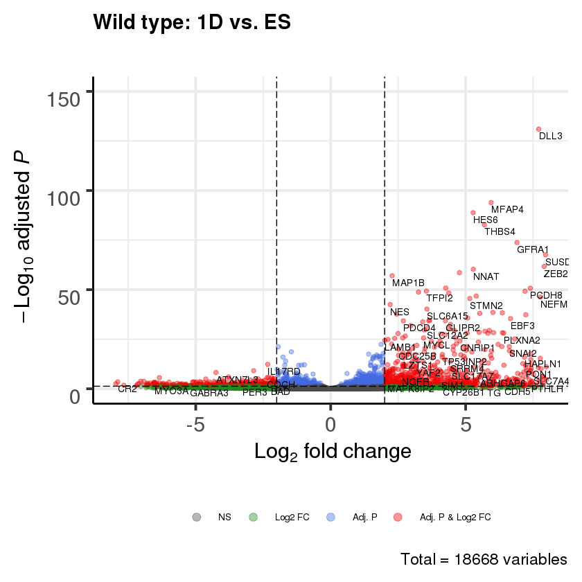

```r
EnhancedVolcano(res3b.df, lab = res3b.df$gene_name, x='log2FoldChange',y='padj', xlim=c(-8,8), ylim=c(0,150),
                xlab = bquote(~Log[2]~ 'fold change'), ylab= bquote(~-Log[10]~adjusted~italic(P)),
                legend=c('NS','Log2 FC','Adj. P', 'Adj. P & Log2 FC'),legendPosition='bottom', legendLabSize = 8,
                legendIconSize = 3.0, title = "Wild type: 1D vs. ES", subtitle="", pCutoff = 0.05, FCcutoff = 2,
                transcriptPointSize = 1.5, transcriptLabSize = 3.0, colAlpha = .4)
# selectLab = c('FHL3', 'STRAG') to only label key transcripts
```

#### 2D vs. WT

```r
res3c <- results(dds3, contrast = c('group','D2','ES'))

# add gene_name to result
if (all(rownames(res3c) == rownames(dds3))) {
    res3c.df <- cbind(res3c, 'gene_name' = mcols(dds3)$gene_name) %>% as.data.frame %>% rownames_to_column('gene_id') %>% filter(!is.na(padj))
}  else {
    print("Rownames don't match!")
}
```

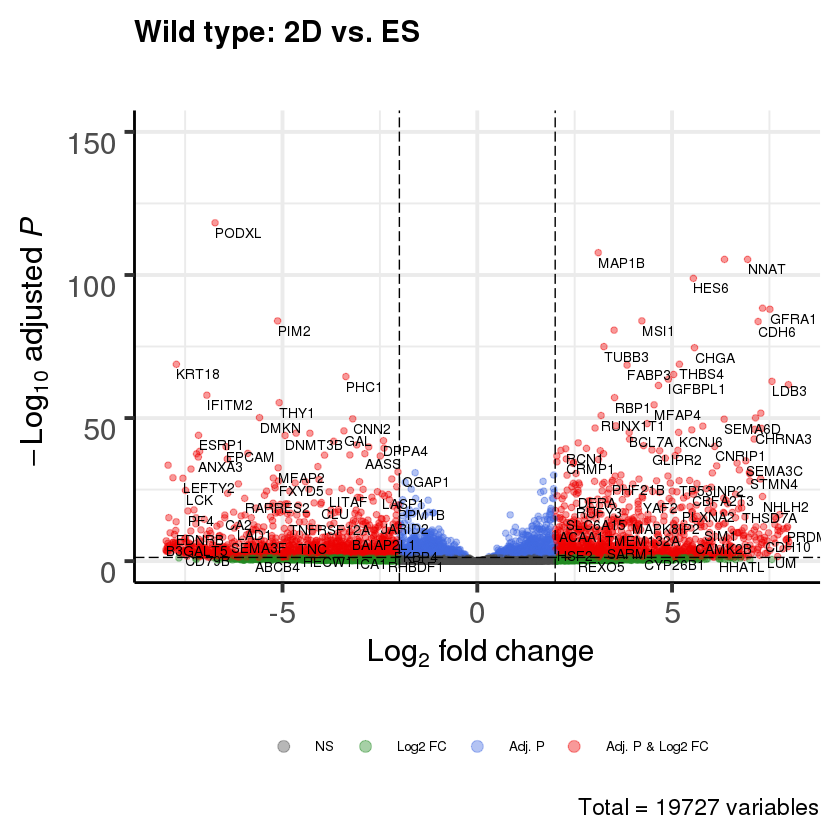

```r
EnhancedVolcano(res3c.df, lab = res3c.df$gene_name, x='log2FoldChange',y='padj', xlim=c(-8,8), ylim=c(0,150),
                xlab = bquote(~Log[2]~ 'fold change'), ylab= bquote(~-Log[10]~adjusted~italic(P)),
                legend=c('NS','Log2 FC','Adj. P', 'Adj. P & Log2 FC'),legendPosition='bottom', legendLabSize = 8,
                legendIconSize = 3.0, title = "Wild type: 2D vs. ES", subtitle="", pCutoff = 0.05, FCcutoff = 2,
                transcriptPointSize = 1.5, transcriptLabSize = 3.0, colAlpha = .4)
# selectLab = c('FHL3', 'STRAG') to only label key transcripts
```

#### 4D vs. WT

```r
res3d <- results(dds3, contrast = c('group','D4','ES'))

# add gene_name to result
if (all(rownames(res3c) == rownames(dds3))) {
    res3d.df <- cbind(res3d, 'gene_name' = mcols(dds3)$gene_name) %>% as.data.frame %>% rownames_to_column('gene_id') %>% filter(!is.na(padj))
}  else {
    print("Rownames don't match!")
}
```

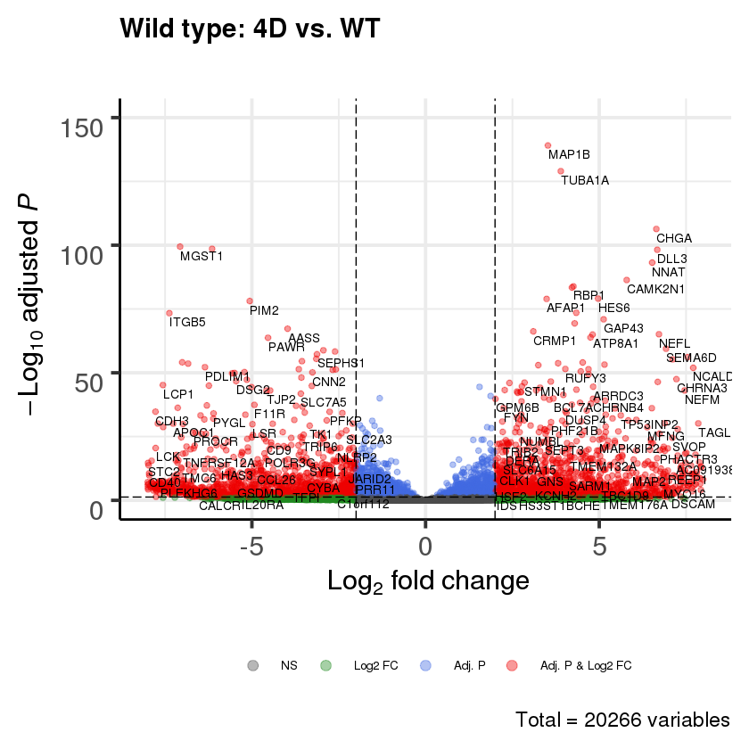

```r
EnhancedVolcano(res3d.df, lab = res3d.df$gene_name, x='log2FoldChange',y='padj', xlim=c(-8,8), ylim=c(0,150),
                xlab = bquote(~Log[2]~ 'fold change'), ylab= bquote(~-Log[10]~adjusted~italic(P)),
                legend=c('NS','Log2 FC','Adj. P', 'Adj. P & Log2 FC'),legendPosition='bottom', legendLabSize = 8,
                legendIconSize = 3.0, title = "Wild type: 4D vs. WT", subtitle="", pCutoff = .05, FCcutoff = 2,
                transcriptPointSize = 1.5, transcriptLabSize = 3.0, colAlpha = .4)
# selectLab = c('FHL3', 'STRAG') to only label key transcripts
```

#### 7D vs. WT

```r
res3e <- results(dds3, contrast = c('group','D7','ES'))

# add gene_name to result
if (all(rownames(res3c) == rownames(dds3))) {
    res3e.df <- cbind(res3e, 'gene_name' = mcols(dds3)$gene_name) %>% as.data.frame %>% rownames_to_column('gene_id') %>% filter(!is.na(padj))
}  else {
    print("Rownames don't match!")
}
```

```r
res3e.df %>% dim
```

1. 20782

2. 8

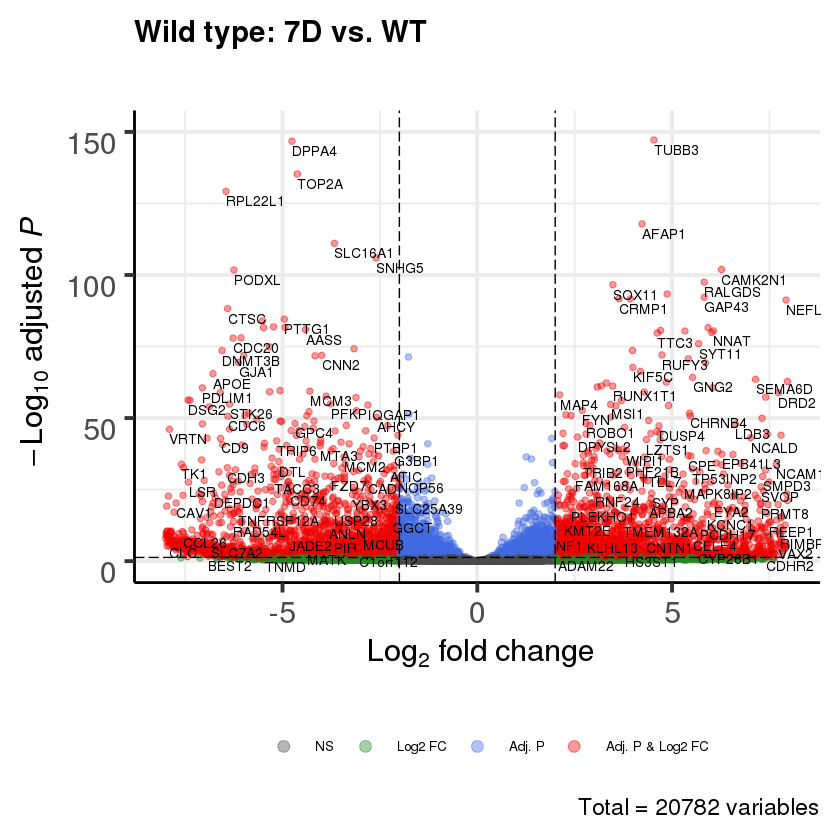

```r
EnhancedVolcano(res3e.df, lab = res3e.df$gene_name, x='log2FoldChange',y='padj', xlim=c(-8,8), ylim=c(0,150),
                xlab = bquote(~Log[2]~ 'fold change'), ylab= bquote(~-Log[10]~adjusted~italic(P)),
                legend=c('NS','Log2 FC','Adj. P', 'Adj. P & Log2 FC'),legendPosition='bottom', legendLabSize = 8,
                legendIconSize = 3.0, title = "Wild type: 7D vs. WT", subtitle="", pCutoff = .05, FCcutoff = 2,
                transcriptPointSize = 1.5, transcriptLabSize = 3.0, colAlpha = .4)
# selectLab = c('FHL3', 'STRAG') to only label key transcripts
```

### Get genes at each temporal point

```r
sig_genes_3a <- res3a.df %>% filter(padj < 0.05) %>% pull('gene_name') %>% unique %>% as.character
sig_genes_3b <- res3b.df %>% filter(padj < 0.05) %>% pull('gene_name') %>% unique %>% as.character
sig_genes_3c <- res3c.df %>% filter(padj < 0.05) %>% pull('gene_name') %>% unique %>% as.character
sig_genes_3d <- res3d.df %>% filter(padj < 0.05) %>% pull('gene_name') %>% unique %>% as.character
sig_genes_3e <- res3e.df %>% filter(padj < 0.05) %>% pull('gene_name') %>% unique %>% as.character
```

```r
res3a.df %>% head
```

A data.frame: 6 × 8

| gene_id <chr> | baseMean <dbl> | log2FoldChange <dbl> | lfcSE <dbl> | stat <dbl> | pvalue <dbl> | padj <dbl> | gene_name <chr> |
| --- | --- | --- | --- | --- | --- | --- | --- |
| ENSG00000000003.14 | 1093.245542 | 0.4627771 | 0.1808703 | 2.5586131 | 0.01050906 | 0.09509573 | TSPAN6 |
| ENSG00000000005.6 | 4.271257 | -0.3569464 | 2.0413513 | -0.1748579 | 0.86119128 | 0.96779725 | TNMD |
| ENSG00000000419.12 | 562.824628 | -0.3726923 | 0.3059226 | -1.2182568 | 0.22312640 | 0.57749445 | DPM1 |
| ENSG00000000457.14 | 66.663959 | -0.5357799 | 0.8261091 | -0.6485584 | 0.51662387 | 0.82276605 | SCYL3 |
| ENSG00000000460.17 | 134.902660 | 0.5850347 | 0.7719233 | 0.7578922 | 0.44851550 | 0.78084051 | C1orf112 |
| ENSG00000001036.13 | 229.696054 | -0.3709913 | 0.2918562 | -1.2711442 | 0.20367734 | 0.55177809 | FUCA2 |

##### Number of genes significant in each tempral profile

```r
sig_genes_3a %>% length
sig_genes_3b %>% length
sig_genes_3c %>% length
sig_genes_3d %>% length
sig_genes_3e %>% length
```

1545

2257

4834

6094

8208

##### Build a matrix that shows how significant genes show up at different time point.

| . | 15H | 1D | 2D | 4D | 7D |
| --- | --- | --- | --- | --- | --- |
| Gene1 | log2FC | log2FC | log2FC | log2FC | log2FC |
| Gene2 |  | log2FC | log2FC | log2FC | log2FC |

... GeneN| | | |log2FC|log2FC

```r
length(c(1,1,1,1,1)==5) & is.numeric(c(1,1,1,1,1))
```

TRUE

```r
# A function to convert a vector of 5 binary numbers (represented in integer) into an integer.
# This esentially represents/flags gene expression time profile.
# e.g. c(1,1,1,1,1) => 31, c(0,0,1,0,0) => 8
bit.like.to.int <- function(c) {
    if (length(c) == 5 & is.numeric(c)){
        return(c[1]*2^4 + c[2]*2^3 + c[3]*2^2 + c[4]*2^1 + c[5]*2^0)
    }
    else {
        print("Vector must be numeric with a length of 5!")
    }
}

# DESeq2 results from each time point, combined into a list
res.all.times <- list(res3a.df, res3b.df, res3c.df, res3d.df, res3e.df)

# first get all significant gene_ids from all 5 time point
sig.geneID.all.times <- c()
fdr.cutoff <- 0.05
for (df in res.all.times) { # iterate through the results from all 5 time points
    geneID.temp <- df %>% filter(padj < fdr.cutoff) %>% pull(gene_id) %>% as.character # get gene_ids of significant genes from results of all 5 time points
    sig.geneID.all.times <- c(sig.geneID.all.times, geneID.temp) # a list of gene ids for all the genes that are significant at any time point
}
sig.geneID.all.times <- unique(sig.geneID.all.times) # remove duplicates gene_ids

# create a expression table with Log2FC at all 5 time points. The rows are genes that are significant at any timepoint.
# Value of NA means the gene is not significant at the given time point

#make a df of gene_id
expr.tbl <- sig.geneID.all.times %>% as.data.frame(stringsAsFactors=F) %>% rename('.'='gene_id')

#create a list of log2FC for all the genes listed in expr.tbl at each time point
FC.all.times <- c()
for (df in res.all.times) {
    x <- expr.tbl %>% left_join(df[df$padj < fdr.cutoff, c('gene_id', 'log2FoldChange')], c('gene_id')) %>%
        select(log2FoldChange) %>% pull(log2FoldChange)
    FC.all.times <- c(FC.all.times, list(x)) # log2FC for the gene_id
}

#add log2FC at each time point as a column, then left join gtf_lookup to add gene name
expr.tbl <- expr.tbl %>% add_column('15H' = FC.all.times[[1]]) %>% add_column('1D' = FC.all.times[[2]]) %>%
             add_column('2D' = FC.all.times[[3]]) %>% add_column('4D' = FC.all.times[[4]]) %>%
             add_column('7D' = FC.all.times[[5]]) %>% left_join(gtf_lookup, 'gene_id')


# create a logic matrix where 1: this gene is significant at this time point, and 0: not
logic.matrix <- apply(expr.tbl[,c(2:6)], MARGIN = 2, function(x) {!is.na(x)}) %>% as.data.frame %>%
        mutate_all(funs(as.integer))

# expression time profile flag. e.g. a number of 7 represents this gene is activated from D2 through D7, while 1 means only activated on D7
expr.flags <- c()
for (i in 1:dim(logic.matrix)[1]) {
    x <- logic.matrix[i,] %>% as.numeric # convert each row e.g.[1,0,0,0,0] into a numeric vector of 5 elements, eg.c(1,0,0,0,0)
    x <- bit.like.to.int(x) # calculate bit value (represented in int, eg. 00100 = 8)
    expr.flags <- c(expr.flags, x)
}

expr.tbl <- cbind(expr.tbl, expr.flag=expr.flags) # add expression flags
expr.tbl <- expr.tbl[,c(1,7:8,2:6)]
```

```r
expr.tbl %>% head
expr.tbl %>% dim
```

A data.frame: 6 × 10

| gene_id <chr> | gene_name <fct> | expr.flag <dbl> | 15H <dbl> | 1D <dbl> | 2D <dbl> | 4D <dbl> | 7D <dbl> | isTF <chr> | isHIT <chr> |
| --- | --- | --- | --- | --- | --- | --- | --- | --- | --- |
| ENSG00000001630.17 | CYP51A1 | 25 | 1.7327958 | 1.2488794 | NA | NA | 1.602056 | No | No |
| ENSG00000002586.20 | CD99 | 30 | 1.2853105 | 0.9205293 | 1.142094 | 0.9041245 | NA | No | No |
| ENSG00000002586.20_PAR_Y | CD99 | 30 | 1.2853105 | 0.9205293 | 1.142094 | 0.9041245 | NA | No | No |
| ENSG00000002834.18 | LASP1 | 31 | -0.9969169 | -1.0071639 | -2.442639 | -1.9664839 | -1.526428 | No | No |
| ENSG00000003249.13 | DBNDD1 | 28 | -2.0081057 | -2.1703805 | -2.555920 | NA | NA | No | No |
| ENSG00000003987.14 | MTMR7 | 17 | -6.3424635 | NA | NA | NA | 2.609631 | No | No |

1. 10438

2. 10

```r
#TF list
tflist <- read.csv('TFlist.csv', stringsAsFactors = F, col.names='gene_name') %>% pull(var = gene_name)
```

```r
#120 hit list
hitlist <- read.csv('HS_td-VStd+_td-VSdox120.csv', header = F, stringsAsFactors = F) %>% pull
```

```r
hitlist %>% t
```

A matrix: 1 × 120 of type chr

| PHOX2A | TAF1L | TFEB | VAX2 | SNAI2 | ELK3 | ISL2 | ZBTB43 | ZNF200 | MLLT6 | ⋯ | ZBTB18 | CHD5 | CTNNB1 | ZNF554 | UBE2K | HTATIP2 | NEUROG3 | SMAD3 | LHX4 | PRDM6 |
| --- | --- | --- | --- | --- | --- | --- | --- | --- | --- | --- | --- | --- | --- | --- | --- | --- | --- | --- | --- | --- |

```r
expr.tbl <- expr.tbl %>% mutate(isTF=if_else(gene_name %in% tflist, 'Yes', 'No')) %>%
             mutate(isHIT=if_else(gene_name %in% hitlist, 'Yes', 'No'))
```

```r
expr.tbl %>% write.csv('FoldChangeByTimePoints.csv', row.names=F)
```

tf.heatmap.genes.3e <- res3e_tf %>% filter(DGE != 'No Change' & padj < fdr & abs(log2FoldChange) > abs(FC.threshold)) %>% pull(gene_name) %>% as.character cnts3_tf[,c(2:16)] %>% filter(gene_name %in% tf.heatmap.genes.3e) %>% column_to_rownames('gene_name') %>% mutate_all(quadroot) %>% as.matrix %>% pheatmap(cluster_rows = T, show_rownames = F, cluster_cols = F, annotation = ano3, fontsize=8, treeheight_row=0, main = paste0('+DOX vs. ES at 7D, Screened TF Genes (fdr<',fdr,', log2FC>',FC.threshold,')'))

##### genes that are significant from 15H to 7D

```r
sig_genes_3a %>% intersect(sig_genes_3b) %>% intersect(sig_genes_3c) %>% intersect(sig_genes_3d) %>%
                 intersect(sig_genes_3e) %>% length
```

569

##### genes that become significant at Day 1 and continues to be significant at Day 2, Day 4 and Day 7

```r
sig_genes_3b %>% setdiff(sig_genes_3a) %>% intersect(sig_genes_3c) %>%
            intersect(sig_genes_3d) %>% intersect(sig_genes_3e) %>% length
```

614

##### genes that become significant at Day 2 and continues to be significant at Day 4 and Day 7

```r
sig_genes_3c %>% setdiff(unique(c(sig_genes_3a,sig_genes_3b))) %>% intersect(sig_genes_3d) %>% intersect(sig_genes_3e) %>% length
```

1914

```r
sig_genes_3e %>% setdiff(unique(c(sig_genes_3a,sig_genes_3b, sig_genes_3c))) %>% intersect(sig_genes_3e) %>% length
```

4077

##### genes that are only significant at Day 7

```r
sig_genes_3e %>% setdiff(unique(c(sig_genes_3a,sig_genes_3b, sig_genes_3c, sig_genes_3d))) %>% length
```

2476

## Zoom in on ~2000 screened TF

```r
#TF list
tflist <- read.csv('TFlist.csv', stringsAsFactors = F, col.names='gene_name') %>% pull(var = gene_name)
```

```r
tflist[1:5]
length(tflist)
```

1. 'AATF'

2. 'ABL1'

3. 'ABT1'

4. 'ABTB1'

5. 'ADNP'

1988

#### Result for each temporal stage

`gene`,`padj`,`log2FoldChange` for each temporal point (15H - 7D) for the 1988 TF genes.

Selection criteria:

- `padj` is not na
- `gene_name` in `tflist`

```r
res3a.df %>% tail
```

A data.frame: 6 × 8

|  | gene_id <chr> | baseMean <dbl> | log2FoldChange <dbl> | lfcSE <dbl> | stat <dbl> | pvalue <dbl> | padj <dbl> | gene_name <chr> |
| --- | --- | --- | --- | --- | --- | --- | --- | --- |
| 18120 | ENSG00000288045.1 | 9.768058 | 0.5958140 | 2.0763235 | 0.2869562 | 0.7741458 | 0.9393474 | AL352979.4 |
| 18121 | ENSG00000288066.1 | 80.563443 | -0.1454350 | 0.4936024 | -0.2946399 | 0.7682690 | 0.9383642 | AC097448.1 |
| 18122 | ENSG00000288075.1 | 16.420657 | -1.3728041 | 1.2551803 | -1.0937107 | 0.2740819 | 0.6329130 | AC108519.1 |
| 18123 | ENSG00000288095.1 | 4.705590 | -0.6852218 | 2.0164201 | -0.3398210 | 0.7339914 | 0.9277397 | AC005618.4 |
| 18124 | ENSG00000288096.1 | 9.268497 | 0.5706050 | 0.9108247 | 0.6264708 | 0.5310062 | 0.8300004 | AC109322.2 |
| 18125 | ENSG00000288105.1 | 4.461664 | 1.0135426 | 0.9510271 | 1.0657347 | 0.2865436 | 0.6464270 | AC117461.1 |

```r
# get DGE result, namely FC and padj, for each temproal point
res3a_tf <- res3a.df %>% filter((gene_name %in% tflist) & (!is.na(padj))) %>% select(gene_name, gene_id, padj, log2FoldChange)
res3b_tf <- res3b.df %>% filter((gene_name %in% tflist) & (!is.na(padj))) %>% select(gene_name, gene_id, padj, log2FoldChange)
res3c_tf <- res3c.df %>% filter((gene_name %in% tflist) & (!is.na(padj))) %>% select(gene_name, gene_id, padj, log2FoldChange)
res3d_tf <- res3d.df %>% filter((gene_name %in% tflist) & (!is.na(padj))) %>% select(gene_name, gene_id, padj, log2FoldChange)
res3e_tf <- res3e.df %>% filter((gene_name %in% tflist) & (!is.na(padj))) %>% select(gene_name, gene_id, padj, log2FoldChange)
```

```r
# Determine and annotate whether a TF screen listed gene is up or down regulated
fdr = 0.05
FC.threshold = 2
```

```r
res3a_tf <- res3a_tf %>% mutate(DGE=case_when(padj < fdr & log2FoldChange > FC.threshold ~ 'Up',
                                  padj < fdr & log2FoldChange < -FC.threshold ~ 'Down',
                                  padj < fdr & log2FoldChange >= -FC.threshold & log2FoldChange <= FC.threshold ~ 'No Change',
                                  padj >= fdr ~ 'No Change'))
res3b_tf <- res3b_tf %>% mutate(DGE=case_when(padj < fdr & log2FoldChange > FC.threshold ~ 'Up',
                                  padj < fdr & log2FoldChange < -FC.threshold ~ 'Down',
                                  padj < fdr & log2FoldChange >= -FC.threshold & log2FoldChange <= FC.threshold ~ 'No Change',
                                  padj >= fdr ~ 'No Change'))
res3c_tf <- res3c_tf %>% mutate(DGE=case_when(padj < fdr & log2FoldChange > FC.threshold ~ 'Up',
                                  padj < fdr & log2FoldChange < -FC.threshold ~ 'Down',
                                  padj < fdr & log2FoldChange >= -FC.threshold & log2FoldChange <= FC.threshold ~ 'No Change',
                                  padj >= fdr ~ 'No Change'))
res3d_tf <- res3d_tf %>% mutate(DGE=case_when(padj < fdr & log2FoldChange > FC.threshold ~ 'Up',
                                  padj < fdr & log2FoldChange < -FC.threshold ~ 'Down',
                                  padj < fdr & log2FoldChange >= -FC.threshold & log2FoldChange <= FC.threshold ~ 'No Change',
                                  padj >= fdr ~ 'No Change'))
res3e_tf <- res3e_tf %>% mutate(DGE=case_when(padj < fdr & log2FoldChange > FC.threshold ~ 'Up',
                                  padj < fdr & log2FoldChange < -FC.threshold ~ 'Down',
                                  padj < fdr & log2FoldChange >= -FC.threshold & log2FoldChange <= FC.threshold ~ 'No Change',
                                  padj >= fdr ~ 'No Change'))
```

```r
#Export to csv
res3a_tf %>% write.csv('TF_Screen_FC_Pval_15HvsES.csv', quote=F)
res3b_tf %>% write.csv('TF_Screen_FC_Pval_1DvsES.csv', quote=F)
res3c_tf %>% write.csv('TF_Screen_FC_Pval_2DvsES.csv', quote=F)
res3d_tf %>% write.csv('TF_Screen_FC_Pval_4DvsES.csv', quote=F)
res3e_tf %>% write.csv('TF_Screen_FC_Pval_7DvsES.csv', quote=F)
```

```r
res3a_tf %>% head
```

A data.frame: 6 × 5

| gene_name <chr> | gene_id <chr> | padj <dbl> | log2FoldChange <dbl> | DGE <chr> |
| --- | --- | --- | --- | --- |
| NFYA | ENSG00000001167.14 | 0.7646300 | 0.2890018 | No Change |
| ARX | ENSG00000004848.8 | 0.4434275 | 2.8463614 | No Change |
| UPF1 | ENSG00000005007.12 | 0.9279808 | 0.1094467 | No Change |
| POLR2J | ENSG00000005075.15 | 0.7763057 | -0.2314939 | No Change |
| CREBBP | ENSG00000005339.14 | 0.1641984 | 0.7450358 | No Change |
| SOX8 | ENSG00000005513.10 | 0.9123444 | -0.6652200 | No Change |

##### Summary plot for TF screen selected genes that are up/down regulated

```r
?gather
```

[output not shown]

Gather columns into key-value pairs.

Description

Usage

[output not shown]

Arguments

[output not shown]

Rules for selection

- A data expression is either a bare name like `x` or an expression like `x:y` or `c(x, y)`. In a data expression, you can only refer to columns from the data frame.

- Everything else is a context expression in which you can only refer to objects that you have defined with `<-`.

For instance, `col1:col3` is a data expression that refers to data columns, while `seq(start, end)` is a context expression that refers to objects from the contexts.

Examples

[output not shown]

[Package *tidyr* version 0.8.3 ]

```r
# summarize gene counts for TF screen selected genes
c <- c()
for (l in list(res3a_tf, res3b_tf, res3c_tf, res3d_tf, res3e_tf)) {
    gcount <- l %>% group_by(DGE) %>% summarize( "gene_count"=n()) %>% pull(gene_count) # get the count of genes
    c <- c(c,gcount)
}

tfs.bar.data <- data.frame(matrix(c, nrow=3))

colnames(tfs.bar.data) = c('15H', '1D', '2D', '4D','7D')
rownames(tfs.bar.data) = c('Down', 'No Change', 'Up')

tfs.bar.data <- tfs.bar.data %>% gather(condition, gene_counts) %>% add_column(DGE=rep(c('Down', 'No Change', 'Up'),5), .before=2)
```

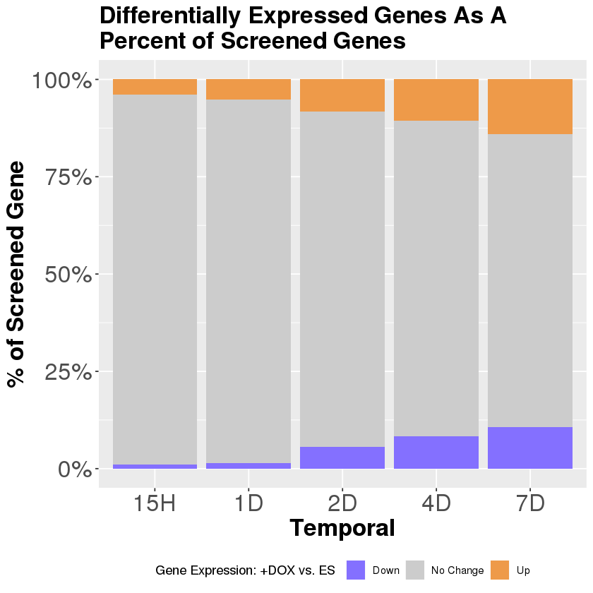

```r
ggplot(data = tfs.bar.data) + geom_bar(aes(x=condition, y=gene_counts, fill=DGE),position=position_fill(reverse = TRUE), stat="identity") +
            labs(y="% of Screened Gene", x="Temporal", title = "Differentially Expressed Genes As A \nPercent of Screened Genes") +
            scale_fill_manual(name='Gene Expression: +DOX vs. ES', values=c('lightslateblue', 'grey80', 'tan2')) +
            theme(axis.text = element_text(size = 20), axis.title=element_text(size=20, face='bold'), legend.position = "bottom",
                  plot.title = element_text(size = 20, face = 'bold')) +
            scale_y_continuous(labels = scales::percent)
```

##### Normalized counts of all TF screen genes, and plot heatmap

```r
cnts3_tf <- (counts(dds3, normalized=T) + 1e-06) %>% as.data.frame %>% rownames_to_column('gene_id') %>%
            inner_join(gtf_lookup, 'gene_id') %>% inner_join(data.frame(gene_name=tflist), 'gene_name')
```

```r
cnts3_tf %>% head
```

A data.frame: 6 × 26

| gene_id <chr> | gene_name <chr> | S01_B1 <dbl> | S01_B2 <dbl> | S02_B1 <dbl> | S02_B2 <dbl> | S13_B1 <dbl> | S13_B2 <dbl> | S14_B1 <dbl> | S14_B2 <dbl> | ⋯ | S18_B1 <dbl> | S18_B2 <dbl> | S19_B1 <dbl> | S19_B2 <dbl> | S20_B1 <dbl> | S20_B2 <dbl> | S21_B1 <dbl> | S21_B2 <dbl> | S22_B1 <dbl> | S22_B2 <dbl> |
| --- | --- | --- | --- | --- | --- | --- | --- | --- | --- | --- | --- | --- | --- | --- | --- | --- | --- | --- | --- | --- |
| ENSG00000001167.14 | NFYA | 173.971134 | 235.480163 | 144.479202 | 197.190345 | 334.096439 | 222.1509939 | 205.399097 | 191.788168 | ⋯ | 281.763803 | 199.1196070 | 241.9922804 | 146.043479 | 298.731463 | 206.009741 | 474.642467 | 292.786077 | 185.781685 | 126.601169 |
| ENSG00000004848.8 | ARX | 0.000001 | 0.000001 | 0.000001 | 0.000001 | 0.000001 | 0.0000010 | 0.000001 | 2.107563 | ⋯ | 0.000001 | 0.6772786 | 0.9166384 | 4.196653 | 24.894290 | 7.823156 | 14.480619 | 0.000001 | 0.000001 | 13.239339 |
| ENSG00000005007.12 | UPF1 | 211.250662 | 199.711025 | 163.410959 | 222.634260 | 195.589122 | 290.4520756 | 299.168249 | 226.914206 | ⋯ | 227.008084 | 187.6058882 | 232.8259062 | 146.043479 | 229.793433 | 211.877107 | 32.179151 | 158.544240 | 176.003701 | 142.322882 |
| ENSG00000005075.15 | POLR2J | 836.718306 | 511.697400 | 573.931171 | 539.092956 | 511.217918 | 342.1953193 | 485.590255 | 408.164562 | ⋯ | 630.831509 | 254.6563678 | 420.7365777 | 506.955523 | 540.972040 | 516.328210 | 672.544241 | 299.729621 | 342.229418 | 359.117039 |
| ENSG00000005102.13 | MEOX1 | 0.000001 | 15.897396 | 0.000001 | 2.385368 | 0.000001 | 0.6899109 | 0.000001 | 0.000001 | ⋯ | 1.140745 | 0.6772786 | 0.0000010 | 0.000001 | 1.914946 | 0.000001 | 8.044789 | 0.000001 | 0.000001 | 5.792211 |
| ENSG00000005339.14 | CREBBP | 135.656063 | 203.685373 | 107.612095 | 244.102563 | 395.375434 | 383.5899143 | 152.933023 | 374.443566 | ⋯ | 159.704180 | 361.6662241 | 435.4027764 | 315.588207 | 295.859045 | 294.020231 | 397.412507 | 337.919109 | 424.643850 | 399.662511 |

```r
cnts3_tf <- cnts3_tf[,c(1,30,2:5, 10:13, 14:29)]
```

```r
# this particular gene has two gene IDs with different expressing profile.
cnts3_tf[,1:2] %>% group_by(gene_name) %>% summarise(n_geneIDs=n_distinct(gene_id)) %>% filter(n_geneIDs > 1)
cnts3_tf %>% filter(gene_name == 'MATR3')
```

A tibble: 1 × 2

| gene_name <chr> | n_geneIDs <int> |
| --- | --- |
| MATR3 | 2 |

A data.frame: 2 × 26

| gene_id <chr> | gene_name <chr> | S01_B1 <dbl> | S01_B2 <dbl> | S02_B1 <dbl> | S02_B2 <dbl> | S13_B1 <dbl> | S13_B2 <dbl> | S14_B1 <dbl> | S14_B2 <dbl> | ⋯ | S18_B1 <dbl> | S18_B2 <dbl> | S19_B1 <dbl> | S19_B2 <dbl> | S20_B1 <dbl> | S20_B2 <dbl> | S21_B1 <dbl> | S21_B2 <dbl> | S22_B1 <dbl> | S22_B2 <dbl> |
| --- | --- | --- | --- | --- | --- | --- | --- | --- | --- | --- | --- | --- | --- | --- | --- | --- | --- | --- | --- | --- |
| ENSG00000015479.18 | MATR3 | 2880.87911 | 3573.933095 | 3662.79684 | 3849.98243 | 2997.63412 | 3721.37409 | 3385.736183 | 3309.575300 | ⋯ | 2819.919509 | 3649.171555 | 3274.228872 | 3694.732131 | 3775.314601 | 3821.611064 | 5476.89137 | 5739.99581 | 4654.32008 | 5189.820418 |
| ENSG00000280987.4 | MATR3 | 69.38135 | 0.000001 | 13.94972 | 43.73173 | 45.32967 | 15.17802 | 0.000001 | 0.000001 | ⋯ | 0.000001 | 0.000001 | 0.000001 | 3.357322 | 0.000001 | 9.127015 | 30.57019 | 15.04434 | 13.96855 | 9.102046 |

```r
cnts3_tf <- filter(cnts3_tf, gene_id != 'ENSG00000280987.4') # remove one gene_id from genes with multiple gene_ids
```

```r
cnts3_tf %>% write.csv('TF_ScreenSelectedNormalizedCounts.csv',row.names=F, quote=F)
```

```r
cnts3_tf %>% head
```

A data.frame: 6 × 26

| gene_id <chr> | gene_name <chr> | S01_B1 <dbl> | S01_B2 <dbl> | S02_B1 <dbl> | S02_B2 <dbl> | S13_B1 <dbl> | S13_B2 <dbl> | S14_B1 <dbl> | S14_B2 <dbl> | ⋯ | S18_B1 <dbl> | S18_B2 <dbl> | S19_B1 <dbl> | S19_B2 <dbl> | S20_B1 <dbl> | S20_B2 <dbl> | S21_B1 <dbl> | S21_B2 <dbl> | S22_B1 <dbl> | S22_B2 <dbl> |
| --- | --- | --- | --- | --- | --- | --- | --- | --- | --- | --- | --- | --- | --- | --- | --- | --- | --- | --- | --- | --- |
| ENSG00000001167.14 | NFYA | 173.971134 | 235.480163 | 144.479202 | 197.190345 | 334.096439 | 222.1509939 | 205.399097 | 191.788168 | ⋯ | 281.763803 | 199.1196070 | 241.9922804 | 146.043479 | 298.731463 | 206.009741 | 474.642467 | 292.786077 | 185.781685 | 126.601169 |
| ENSG00000004848.8 | ARX | 0.000001 | 0.000001 | 0.000001 | 0.000001 | 0.000001 | 0.0000010 | 0.000001 | 2.107563 | ⋯ | 0.000001 | 0.6772786 | 0.9166384 | 4.196653 | 24.894290 | 7.823156 | 14.480619 | 0.000001 | 0.000001 | 13.239339 |
| ENSG00000005007.12 | UPF1 | 211.250662 | 199.711025 | 163.410959 | 222.634260 | 195.589122 | 290.4520756 | 299.168249 | 226.914206 | ⋯ | 227.008084 | 187.6058882 | 232.8259062 | 146.043479 | 229.793433 | 211.877107 | 32.179151 | 158.544240 | 176.003701 | 142.322882 |
| ENSG00000005075.15 | POLR2J | 836.718306 | 511.697400 | 573.931171 | 539.092956 | 511.217918 | 342.1953193 | 485.590255 | 408.164562 | ⋯ | 630.831509 | 254.6563678 | 420.7365777 | 506.955523 | 540.972040 | 516.328210 | 672.544241 | 299.729621 | 342.229418 | 359.117039 |
| ENSG00000005102.13 | MEOX1 | 0.000001 | 15.897396 | 0.000001 | 2.385368 | 0.000001 | 0.6899109 | 0.000001 | 0.000001 | ⋯ | 1.140745 | 0.6772786 | 0.0000010 | 0.000001 | 1.914946 | 0.000001 | 8.044789 | 0.000001 | 0.000001 | 5.792211 |
| ENSG00000005339.14 | CREBBP | 135.656063 | 203.685373 | 107.612095 | 244.102563 | 395.375434 | 383.5899143 | 152.933023 | 374.443566 | ⋯ | 159.704180 | 361.6662241 | 435.4027764 | 315.588207 | 295.859045 | 294.020231 | 397.412507 | 337.919109 | 424.643850 | 399.662511 |

```r
ano3 <- as.data.frame(colData(dds3)[,c('condition','group')])
```

cnts3_tf[,c(2:16)] %>% column_to_rownames('gene_name') %>% as.matrix %>% pheatmap(cluster_rows = T, show_rownames = T, cluster_cols = F, annotation = ano3, fontsize=5, title = 'TF Selected in Screen', filename='TF_screen_selected.heatmap.pdf', width=8, height=66, silent=T)

```r
quadroot <- function (x) { # function to help decrease range of read counts. Easier for heatmap visulization
    return(x^(1/4))
}
```

```r
ano3 <- as.data.frame(colData(dds3)[,c('condition','group')]) #annotation for heatmap
```

```r
cnts3_tf %>% head
```

A data.frame: 6 × 26

| gene_id <chr> | gene_name <chr> | S01_B1 <dbl> | S01_B2 <dbl> | S02_B1 <dbl> | S02_B2 <dbl> | S13_B1 <dbl> | S13_B2 <dbl> | S14_B1 <dbl> | S14_B2 <dbl> | ⋯ | S18_B1 <dbl> | S18_B2 <dbl> | S19_B1 <dbl> | S19_B2 <dbl> | S20_B1 <dbl> | S20_B2 <dbl> | S21_B1 <dbl> | S21_B2 <dbl> | S22_B1 <dbl> | S22_B2 <dbl> |
| --- | --- | --- | --- | --- | --- | --- | --- | --- | --- | --- | --- | --- | --- | --- | --- | --- | --- | --- | --- | --- |
| ENSG00000001167.14 | NFYA | 173.971134 | 235.480163 | 144.479202 | 197.190345 | 334.096439 | 222.1509939 | 205.399097 | 191.788168 | ⋯ | 281.763803 | 199.1196070 | 241.9922804 | 146.043479 | 298.731463 | 206.009741 | 474.642467 | 292.786077 | 185.781685 | 126.601169 |
| ENSG00000004848.8 | ARX | 0.000001 | 0.000001 | 0.000001 | 0.000001 | 0.000001 | 0.0000010 | 0.000001 | 2.107563 | ⋯ | 0.000001 | 0.6772786 | 0.9166384 | 4.196653 | 24.894290 | 7.823156 | 14.480619 | 0.000001 | 0.000001 | 13.239339 |
| ENSG00000005007.12 | UPF1 | 211.250662 | 199.711025 | 163.410959 | 222.634260 | 195.589122 | 290.4520756 | 299.168249 | 226.914206 | ⋯ | 227.008084 | 187.6058882 | 232.8259062 | 146.043479 | 229.793433 | 211.877107 | 32.179151 | 158.544240 | 176.003701 | 142.322882 |
| ENSG00000005075.15 | POLR2J | 836.718306 | 511.697400 | 573.931171 | 539.092956 | 511.217918 | 342.1953193 | 485.590255 | 408.164562 | ⋯ | 630.831509 | 254.6563678 | 420.7365777 | 506.955523 | 540.972040 | 516.328210 | 672.544241 | 299.729621 | 342.229418 | 359.117039 |
| ENSG00000005102.13 | MEOX1 | 0.000001 | 15.897396 | 0.000001 | 2.385368 | 0.000001 | 0.6899109 | 0.000001 | 0.000001 | ⋯ | 1.140745 | 0.6772786 | 0.0000010 | 0.000001 | 1.914946 | 0.000001 | 8.044789 | 0.000001 | 0.000001 | 5.792211 |
| ENSG00000005339.14 | CREBBP | 135.656063 | 203.685373 | 107.612095 | 244.102563 | 395.375434 | 383.5899143 | 152.933023 | 374.443566 | ⋯ | 159.704180 | 361.6662241 | 435.4027764 | 315.588207 | 295.859045 | 294.020231 | 397.412507 | 337.919109 | 424.643850 | 399.662511 |

##### Plot heatmaps of TF screened genes that are sigificant and pass FC threshold

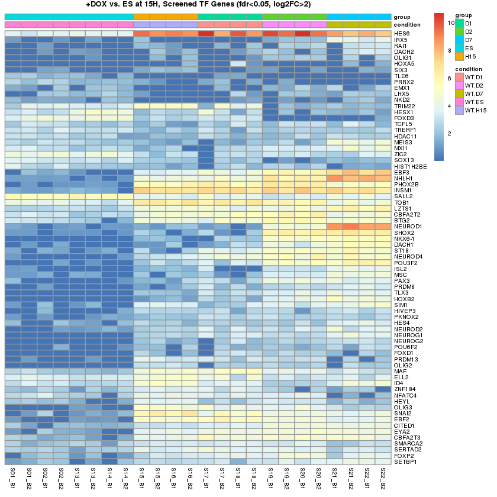

```r
tf.heatmap.genes.3a <- res3a_tf %>% filter(DGE != 'No Change' & padj < fdr & abs(log2FoldChange) > abs(FC.threshold)) %>% pull(gene_name) %>% as.character
cnts3_tf[,c(2:26)] %>% filter(gene_name %in% tf.heatmap.genes.3a) %>% column_to_rownames('gene_name') %>% as.matrix %>% apply(2, quadroot) %>%
                pheatmap(cluster_rows = T, show_rownames = T, cluster_cols = F, annotation = ano3, fontsize=6, treeheight_row=0,
                main = paste0('+DOX vs. ES at 15H, Screened TF Genes (fdr<',fdr,', log2FC>',FC.threshold,')'))
```

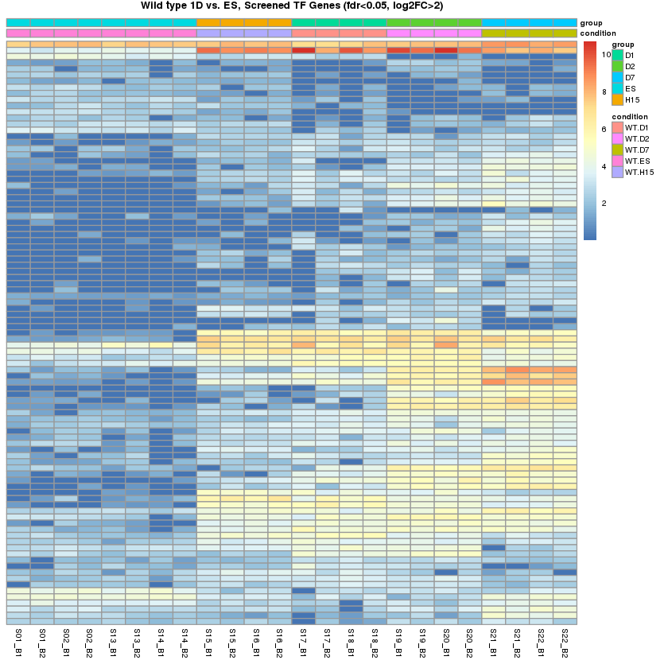

```r
tf.heatmap.genes.3b <- res3b_tf %>% filter(DGE != 'No Change' & padj < fdr & abs(log2FoldChange) > abs(FC.threshold)) %>% pull(gene_name) %>% as.character
cnts3_tf[,c(2:26)] %>% filter(gene_name %in% tf.heatmap.genes.3b) %>% column_to_rownames('gene_name') %>% as.matrix %>% apply(2, quadroot) %>%
                pheatmap(cluster_rows = T, show_rownames = F, cluster_cols = F, annotation = ano3, fontsize=6, treeheight_row=0,
                main = paste0('Wild type 1D vs. ES, Screened TF Genes (fdr<',fdr,', log2FC>',FC.threshold,')'))
```

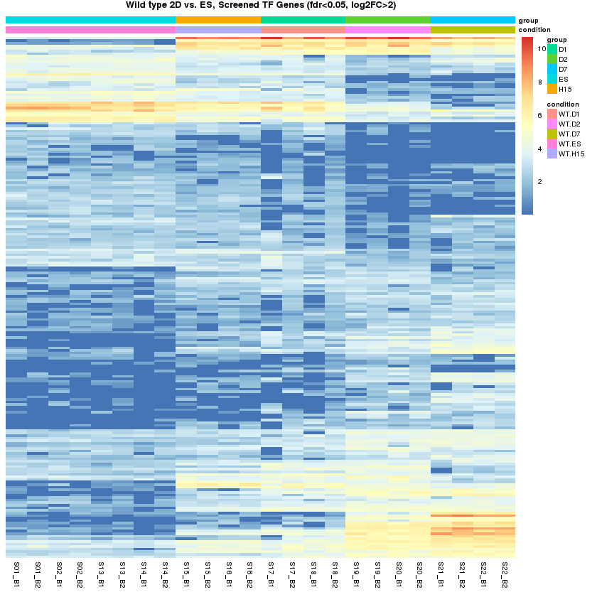

```r
tf.heatmap.genes.3c <- res3c_tf %>% filter(DGE != 'No Change' & padj < fdr & abs(log2FoldChange) > abs(FC.threshold)) %>% pull(gene_name) %>% as.character
cnts3_tf[,c(2:26)] %>% filter(gene_name %in% tf.heatmap.genes.3c) %>% column_to_rownames('gene_name') %>% as.matrix %>% apply(2, quadroot) %>%
                pheatmap(cluster_rows = T, show_rownames = F, cluster_cols = F, annotation = ano3, fontsize=6, treeheight_row=0,
                main = paste0('Wild type 2D vs. ES, Screened TF Genes (fdr<',fdr,', log2FC>',FC.threshold,')'))
```

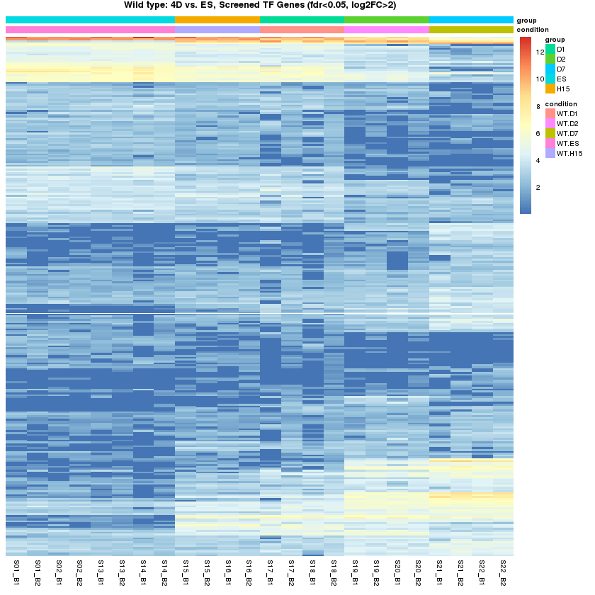

```r
tf.heatmap.genes.3d <- res3d_tf %>% filter(DGE != 'No Change' & padj < fdr & abs(log2FoldChange) > abs(FC.threshold)) %>% pull(gene_name) %>% as.character
cnts3_tf[,c(2:26)] %>% filter(gene_name %in% tf.heatmap.genes.3d) %>% column_to_rownames('gene_name') %>% as.matrix %>% apply(2, quadroot) %>%
                pheatmap(cluster_rows = T, show_rownames = F, cluster_cols = F, annotation = ano3, fontsize=6, treeheight_row=0,
                main = paste0('Wild type: 4D vs. ES, Screened TF Genes (fdr<',fdr,', log2FC>',FC.threshold,')'))
```

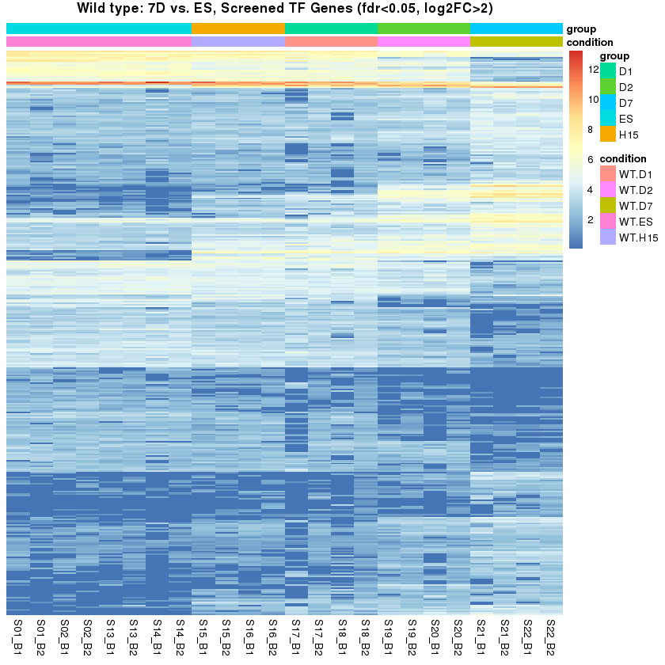

```r
tf.heatmap.genes.3e <- res3e_tf %>% filter(DGE != 'No Change' & padj < fdr & abs(log2FoldChange) > abs(FC.threshold)) %>% pull(gene_name) %>% as.character
cnts3_tf[,c(2:26)] %>% filter(gene_name %in% tf.heatmap.genes.3e) %>% column_to_rownames('gene_name') %>% as.matrix %>% apply(2, quadroot) %>%
                pheatmap(cluster_rows = T, show_rownames = F, cluster_cols = F, annotation = ano3, fontsize=8, treeheight_row=0,
                main = paste0('Wild type: 7D vs. ES, Screened TF Genes (fdr<',fdr,', log2FC>',FC.threshold,')'))
```

```r
for (x in list(tf.heatmap.genes.3a, tf.heatmap.genes.3b, tf.heatmap.genes.3c, tf.heatmap.genes.3d, tf.heatmap.genes.3e)) {
    print(length(x))
}
```

```
[1] 72
[1] 95
[1] 202
[1] 276
[1] 366
```

```r
tf.heatmap.genes.3a %>% sort %>% paste(" ", collapse="") # 15H up or down regulated
```

'BTG2 CBFA2T2 CBFA2T3 CITED1 DACH1 DACH2 EBF2 EBF3 ELL2 EMX1 EYA2 FOXD1 FOXD3 FOXP2 HDAC11 HES4 HES6 HESX1 HEYL HIST1H2BE HIVEP3 HOXA5 HOXB2 ID4 INSM1 IRX5 ISL2 LHX5 LZTS1 MAF MEIS3 MSC MXI1 NEUROD1 NEUROD2 NEUROD4 NEUROG1 NEUROG2 NFATC4 NHLH1 NKD2 NKX6-1 OLIG1 OLIG2 OLIG3 PAX3 PHOX2B PKNOX2 POU3F2 POU6F2 PRDM13 PRDM8 PRRX2 RAI1 SALL2 SERTAD2 SETBP1 SHOX2 SIM1 SIX3 SMARCA2 SNAI2 SOX13 ST18 TCFL5 TLE6 TLX3 TOB1 TRERF1 TRIM22 ZIC2 ZNF184 '

```r
tf.heatmap.genes.3b %>% sort %>% paste(" ", collapse="") # 1D up or down regulated
```

'AFF3 BACH2 BARX1 BRF1 BTG2 CBFA2T2 CBFA2T3 CITED1 DACH1 DENND4A E2F1 EBF2 EBF3 ESRRA ETV4 EYA2 FOXD1 FOXP2 GATA6 GBX2 HABP4 HES2 HES4 HES6 HIVEP3 HOXA5 HOXB2 IFI16 INSM1 INSM2 IRX2 ISL1 ISL2 LHX9 LMO1 LMO3 LZTS1 MAF MATR3 MEIS1 MEIS3 MSC NEUROD2 NEUROD4 NEUROG1 NEUROG2 NHLH1 NHLH2 NKX6-1 NR4A1 NR4A2 NRL OLIG2 OLIG3 ONECUT2 OVOL2 PAX3 PDLIM4 PER3 PHOX2B PKNOX2 POU3F2 POU6F2 PRDM13 PRDM8 RAI1 RARG RCOR2 RELB RXRG SCRT2 SERTAD2 SETBP1 SHOX2 SIM1 SIX4 SMARCA2 SNAI2 SOX13 ST18 STAT5A TBC1D2B TCF12 TLE2 TLX2 TLX3 TOB1 TSHZ1 VAX2 YAF2 ZBTB10 ZHX3 ZIC2 ZNF184 ZNF491 '

```r
tf.heatmap.genes.3c %>% sort %>% paste(" ", collapse="") # 2D up or down regulated
```

'AFF3 AHR ANKRD53 ARX BACH2 BCL11A BCL11B BCL6B BTG2 CALCOCO1 CBFA2T2 CBFA2T3 CDX4 CHD7 CITED1 CRABP2 CREB5 DACH1 DACH2 DENND4A DMRTA1 E2F1 E2F2 EBF2 EBF3 ELAVL2 ELF3 ELF4 EPAS1 ERF ESRRA ESRRG ETV4 EYA2 FHL2 FOS FOSL1 FOXA2 FOXA3 FOXD1 FOXD3 FOXH1 FOXP2 GATA6 GLI1 GLI2 HES1 HES2 HES4 HES6 HESX1 HEY1 HEYL HIF3A HIST2H2BE HIVEP2 HIVEP3 HOXB2 HSF2 ID3 INSM1 INSM2 IRF6 IRX2 IRX5 ISL1 ISL2 JARID2 JDP2 KLF12 KLF13 KLF4 LDB2 LHX1 LHX9 LMO1 LZTS1 MAF MEF2C MEIS1 MSC MXD3 MYC MYT1 NANOG NEUROD1 NEUROD2 NEUROD4 NEUROG1 NEUROG2 NFKBIZ NHLH1 NHLH2 NKX6-1 NOTCH3 NPM2 NR4A1 NR5A2 NRIP1 NRL OLIG1 OLIG2 OLIG3 ONECUT2 OVOL1 OVOL2 PAWR PAX3 PAX5 PBXIP1 PDLIM1 PDLIM4 PEG3 PER3 PHF21B PHOX2A PHOX2B PKNOX2 POU2F2 POU3F2 POU5F1 POU6F2 PRDM13 PRDM2 PRDM8 PROX1 PRRX2 PYGO1 RAI1 RARG RCOR2 RUNX1T1 RXRG SALL2 SATB2 SCML1 SCRT1 SCRT2 SERTAD2 SETBP1 SHOX2 SIM1 SIRT2 SIX1 SMARCA2 SNAI2 SOX10 SOX13 SOX15 SOX2 SOX21 SOX3 SOX5 SOX7 SP110 SP140 SPIB SSBP2 ST18 STAT5A STAT6 TAF4B TBC1D2B TCF12 TCF15 TEAD4 TFE3 TGFB1I1 TLE2 TLE6 TLX2 TLX3 TOB1 TRIB3 TRIM22 TRIM25 TSC22D3 TSHZ1 TSHZ2 UTF1 VAX2 VENTX YAF2 YBX2 ZBTB10 ZBTB20 ZBTB22 ZBTB3 ZFP36 ZFP57 ZHX3 ZIC3 ZNF114 ZNF165 ZNF222 ZNF398 ZNF483 ZNF486 ZNF491 ZNF589 ZNF596 ZNF688 '

```r
tf.heatmap.genes.3d %>% sort %>% paste(" ", collapse="") # 4D up or down regulated
```

'AEBP1 AFF3 AHR APBB1 AR ARX ASB8 ASB9 ATF3 BACH2 BCL11A BCL11B BCL6B BTG2 CALCOCO1 CASZ1 CBFA2T2 CBFA2T3 CBX8 CDX4 CEBPB CHAF1A CHD7 CITED1 CRABP2 CREB3L1 CREG1 CSDC2 DACH1 DACH2 DDX54 DENND4A DIP2C DMRTA1 EBF2 EBF3 ELAVL2 ELF3 ELF4 ELK1 ERF ESPL1 ESRRA ESRRG ETS1 ETV4 EYA2 FHL2 FOS FOSL1 FOXA2 FOXA3 FOXB1 FOXD1 FOXD3 FOXF1 FOXH1 FOXP2 FOXP4 GATA6 GLI1 GLI2 HDAC10 HDAC4 HDAC9 HES4 HES6 HESX1 HEY1 HEY2 HEYL HIF3A HIST1H1C HIST1H1D HIST1H2BJ HIST2H2BE HIVEP3 HMGA1 HOXB2 HSF2 HTATIP2 ID3 ING4 INSM1 INSM2 IRF3 IRF6 IRX1 IRX3 IRX5 ISL1 ISL2 JARID2 JDP2 JUNB KLF12 KLF13 KLF15 KLF4 KLF5 KLF9 LDB2 LHX2 LHX4 LHX9 LMO1 LZTR1 LZTS1 MAF MAML3 MCM3 MCM5 MEF2C MEIS1 MEIS2 MLLT6 MLXIPL MSC MTA3 MXD4 MYB MYT1 MYT1L NANOG NEUROD1 NEUROD2 NEUROD4 NEUROG1 NEUROG2 NFKBIZ NHLH1 NHLH2 NKX6-1 NKX6-2 NMI NOTCH3 NPAS3 NPM1 NPM2 NR1H3 NR2F1 NR4A1 NR5A2 NRIP1 OLIG1 OLIG2 OLIG3 ONECUT2 OVOL1 OVOL2 PAWR PAX3 PAX6 PBX4 PDLIM1 PER3 PHF13 PHF19 PHF21B PHOX2A PHOX2B PIR PITX2 PKNOX2 POLR1B POLR2J2 POU3F2 POU3F3 POU4F1 POU4F2 POU5F1 PPAN PRDM13 PRDM2 PRDM6 PRDM8 PROX1 PRRX2 PYGO1 RAI1 RARG RELB REST RORA RUNX1T1 RXRG SALL2 SALL4 SATB1 SATB2 SCRT1 SCRT2 SEC14L2 SETBP1 SHOX2 SIM1 SIRT2 SIX1 SIX3 SMAD9 SNAI2 SNAI3 SOX11 SOX13 SOX15 SOX2 SOX21 SOX3 SOX5 SOX7 SP110 SP140 SPIB SSBP2 ST18 STAT5A STAT6 TAF4B TBX3 TCF12 TCF15 TCF7L1 TEAD4 TLE2 TLE6 TLX1 TLX2 TLX3 TOX TRIM22 TRIM25 TRIM5 TRIP13 TRIP6 TSC22D3 TSHZ1 TSHZ2 TSHZ3 TULP4 UTF1 VAX2 VENTX WDHD1 WWTR1 YAF2 YBX2 ZBTB10 ZBTB20 ZBTB7B ZFP2 ZFP36L2 ZFP42 ZFP57 ZHX1 ZHX3 ZIC3 ZNF165 ZNF25 ZNF250 ZNF256 ZNF398 ZNF436 ZNF441 ZNF446 ZNF491 ZNF546 ZNF568 ZNF589 ZNF595 ZNF596 ZNF599 ZNF611 ZNF624 ZNF641 ZNF688 ZNF709 '

```r
tf.heatmap.genes.3e %>% sort %>% paste(" ", collapse="") # 7D up or down regulated
```

'AEBP1 AFF1 AFF3 AHR APBB1 APC AR ARNT2 ASB8 ASB9 ATF5 BACH2 BARX1 BAZ2B BCL6B BRCA2 BRIP1 BTG2 CALCOCO1 CBFA2T2 CBFA2T3 CBX4 CBX8 CDX4 CEBPB CHAF1A CHD7 CITED1 CRABP2 CREB5 CREG1 CRTC1 CTDSPL DAB2 DACH1 DACH2 DAXX DBP DDIT3 DDX54 DENND4A DIP2C DNMT1 DPF3 E2F3 E2F8 EBF2 EBF3 ELAVL2 ELF3 ELF4 ENO1 ESPL1 ESRRA ESRRG ETS1 ETV4 EYA2 FHL2 FOSL1 FOXA2 FOXA3 FOXD1 FOXD3 FOXF2 FOXH1 FOXM1 FOXP2 GATA3 GLI1 GLI2 GLI3 GTF2I HABP4 HDAC1 HDAC4 HDAC9 HES1 HES4 HES6 HESX1 HEY1 HEY2 HIC2 HIST1H1B HIST1H1C HIST1H1D HIST1H2BD HIST1H2BE HIST1H2BH HIST1H2BJ HIST2H2BE HIVEP3 HMGA1 HMGA2 HMGN3 HOXA5 HOXB2 HOXB3 HOXD9 HTATIP2 ID1 ID3 ID4 ING4 INSM1 INSM2 IRF6 IRX1 IRX3 IRX5 ISL1 ISL2 JDP2 JUN KLF11 KLF12 KLF13 KLF15 KLF4 KLF5 KLF7 LDB2 LHX2 LHX4 LHX9 LIMD1 LMO1 LZTS1 MAFB MAFK MAML3 MCM2 MCM3 MCM4 MCM5 MCM6 MEF2B MEF2C MEIS1 MEIS2 MEIS3 MLLT6 MLXIPL MSC MTA3 MXD1 MXD4 MXI1 MYB MYBBP1A MYBL2 MYEF2 MYT1 MYT1L NANOG NCOA1 NCOA6 NEUROD1 NEUROD2 NEUROD4 NEUROG1 NEUROG2 NFATC4 NFIA NFKBIZ NFXL1 NHLH1 NHLH2 NKX6-1 NKX6-2 NME2 NMI NOTCH2 NOTCH3 NPAS3 NPM1 NPM2 NR1H2 NR1H3 NR2F1 NR2F2 NR4A1 NR4A2 NR4A3 NR5A2 NRIP1 OLIG1 OLIG2 OLIG3 ONECUT2 OVOL1 OVOL2 PAWR PAX3 PAX5 PBX4 PDLIM1 PHF19 PHF2 PHF21B PHOX2A PHOX2B PIR PKNOX2 PLAGL1 POLR3K POU2F2 POU3F2 POU3F3 POU4F1 POU4F2 POU5F1 POU6F2 PPAN PRDM13 PRDM2 PRDM4 PRDM6 PRDM8 PROX1 PRRX2 PTTG1 PYGO1 RAD51 RAD54B RAI1 RARG RBL1 RELB REST RFX3 RORA RREB1 RUNX1T1 RXRG SALL4 SATB2 SCRT1 SCRT2 SEC14L2 SETBP1 SHOX2 SIM1 SIM2 SIRT2 SIX1 SIX5 SMAD1 SMAD3 SMAD6 SMAD7 SMAD9 SMARCC2 SNAI2 SNRPB SOX10 SOX11 SOX13 SOX15 SOX2 SOX21 SOX3 SOX5 SOX6 SOX7 SP110 SP140 SPIB SS18L1 SSBP2 ST18 STAT6 TAF4B TBX3 TCF19 TCF7L1 TCF7L2 TEAD4 TFCP2L1 TFE3 TGIF2 THRA TLE1 TLE2 TLE6 TLX1 TLX3 TRIM22 TRIM25 TRIM28 TRIM5 TRIP13 TRIP4 TRIP6 TSC22D1 TSC22D3 TSHZ1 TSHZ2 TTF2 TULP4 UTF1 VAX2 WDHD1 WWTR1 XRCC3 YAF2 ZBTB10 ZBTB20 ZBTB22 ZBTB3 ZBTB7B ZFP2 ZFP28 ZFP30 ZFP36 ZFP36L1 ZFP36L2 ZFP37 ZFP42 ZFP57 ZFP90 ZHX1 ZHX3 ZIC3 ZKSCAN1 ZNF10 ZNF117 ZNF160 ZNF165 ZNF25 ZNF250 ZNF300 ZNF333 ZNF34 ZNF341 ZNF358 ZNF382 ZNF41 ZNF436 ZNF440 ZNF441 ZNF45 ZNF471 ZNF483 ZNF491 ZNF513 ZNF540 ZNF546 ZNF556 ZNF558 ZNF568 ZNF570 ZNF583 ZNF589 ZNF596 ZNF606 ZNF624 ZNF627 ZNF641 ZNF646 ZNF653 ZNF688 ZNF695 ZNF709 ZNF83 '

tf.heatmap.genes.3a.up <- res3a_tf %>% filter(DGE != 'Up' & padj < fdr & abs(log2FoldChange) > abs(FC.threshold)) %>% pull(gene_name) %>% as.character tf.heatmap.genes.3b.up <- res3b_tf %>% filter(DGE != 'Up' & padj < fdr & abs(log2FoldChange) > abs(FC.threshold)) %>% pull(gene_name) %>% as.character tf.heatmap.genes.3c.up <- res3c_tf %>% filter(DGE != 'Up' & padj < fdr & abs(log2FoldChange) > abs(FC.threshold)) %>% pull(gene_name) %>% as.character tf.heatmap.genes.3d.up <- res3d_tf %>% filter(DGE != 'Up' & padj < fdr & abs(log2FoldChange) > abs(FC.threshold)) %>% pull(gene_name) %>% as.character tf.heatmap.genes.3e.up <- res3e_tf %>% filter(DGE != 'Up' & padj < fdr & abs(log2FoldChange) > abs(FC.threshold)) %>% pull(gene_name) %>% as.character tf.heatmap.genes.3a.down <- res3a_tf %>% filter(DGE != 'Down' & padj < fdr & abs(log2FoldChange) > abs(FC.threshold)) %>% pull(gene_name) %>% as.character tf.heatmap.genes.3b.down <- res3b_tf %>% filter(DGE != 'Down' & padj < fdr & abs(log2FoldChange) > abs(FC.threshold)) %>% pull(gene_name) %>% as.character tf.heatmap.genes.3c.down <- res3c_tf %>% filter(DGE != 'Down' & padj < fdr & abs(log2FoldChange) > abs(FC.threshold)) %>% pull(gene_name) %>% as.character tf.heatmap.genes.3d.down <- res3d_tf %>% filter(DGE != 'Down' & padj < fdr & abs(log2FoldChange) > abs(FC.threshold)) %>% pull(gene_name) %>% as.character tf.heatmap.genes.3e.down <- res3e_tf %>% filter(DGE != 'Down' & padj < fdr & abs(log2FoldChange) > abs(FC.threshold)) %>% pull(gene_name) %>% as.character # SAVE gene names in the heatmaps to csv. Note, the values of variables such as tf.heatmap.genes.3a would have changed after running this code block tf.heatmap.genes.up.df = data.frame(matrix(NA, length(tf.heatmap.genes.3e.up), 0)) tf.heatmap.genes.3a.up <- append(tf.heatmap.genes.3a.up, rep(NA, length(tf.heatmap.genes.3e.up) - length(tf.heatmap.genes.3a.up))) tf.heatmap.genes.3b.up <- append(tf.heatmap.genes.3b.up, rep(NA, length(tf.heatmap.genes.3e.up) - length(tf.heatmap.genes.3b.up))) tf.heatmap.genes.3c.up <- append(tf.heatmap.genes.3c.up, rep(NA, length(tf.heatmap.genes.3e.up) - length(tf.heatmap.genes.3c.up))) tf.heatmap.genes.3d.up <- append(tf.heatmap.genes.3d.up, rep(NA, length(tf.heatmap.genes.3e.up) - length(tf.heatmap.genes.3d.up))) tf.heatmap.genes.up.df %>% add_column('15H' = tf.heatmap.genes.3a.up) %>% add_column('1D' = tf.heatmap.genes.3b.up) %>% add_column('2D' = tf.heatmap.genes.3c.up) %>% add_column('4D' = tf.heatmap.genes.3d.up) %>% add_column('7D' = tf.heatmap.genes.3e.up) %>% write.csv('tf.heatmap.genes.up.csv', quote=F)# SAVE gene names in the heatmaps to csv. Note, the values of variables such as tf.heatmap.genes.3a would have changed after running this code block tf.heatmap.genes.down.df = data.frame(matrix(NA, length(tf.heatmap.genes.3e.down), 0)) tf.heatmap.genes.3a.down <- append(tf.heatmap.genes.3a.down, rep(NA, length(tf.heatmap.genes.3e.down) - length(tf.heatmap.genes.3a.down))) tf.heatmap.genes.3b.down <- append(tf.heatmap.genes.3b.down, rep(NA, length(tf.heatmap.genes.3e.down) - length(tf.heatmap.genes.3b.down))) tf.heatmap.genes.3c.down <- append(tf.heatmap.genes.3c.down, rep(NA, length(tf.heatmap.genes.3e.down) - length(tf.heatmap.genes.3c.down))) tf.heatmap.genes.3d.down <- append(tf.heatmap.genes.3d.down, rep(NA, length(tf.heatmap.genes.3e.down) - length(tf.heatmap.genes.3d.down))) tf.heatmap.genes.down.df %>% add_column('15H' = tf.heatmap.genes.3a.down) %>% add_column('1D' = tf.heatmap.genes.3b.down) %>% add_column('2D' = tf.heatmap.genes.3c.down) %>% add_column('4D' = tf.heatmap.genes.3d.down) %>% add_column('7D' = tf.heatmap.genes.3e.down) %>% write.csv('tf.heatmap.genes.down.csv', quote=F)

# Other

> *If you can't explain it simply, you don't understand it well enough.*